# Stats Diamonds Project Notebook

8:15 Wednesday section, Group 6 Manpreet, Tulsi, TJ, Jonathan

This code’s purpose is to focus on external data sources for diamond pricing, to see if they are compatible with the project dataset and the model we have developed.

The code will: Read in original data plus external brand data Then combine into single dataframe “diamonds” Add a new column “vendor” The original data has value “vendor” == “Original”

```r
orig_diamonds= read.csv("diamonds4.csv")
orig_diamonds = data.frame(orig_diamonds)
orig_diamonds$vendor = "Original"

extra_diamonds= read.csv("extra_diamonds.csv")
extra_diamonds = data.frame(extra_diamonds)
keep_columns = c("carat","clarity","color","cut","price","vendor")
extra_diamonds = extra_diamonds[keep_columns]

# Merge the external data and original
# So that transformations occur in the same way to both types
diamonds <- rbind(extra_diamonds, orig_diamonds)

# preserve original values for price and carat, pre-transform
# So that we can continue to refer to them in terms that
# make sense to the customer
diamonds$o_price <- diamonds$price
diamonds$o_carat <- diamonds$carat
```

Reduce categories for model simplicity. The justification for these is in the EDA section of our project document.

```r
library(MASS)
library(dplyr)
#EDA for project

diamonds$clarity = factor(diamonds$clarity)
diamonds$cut= factor(diamonds$cut)
diamonds$color =factor(diamonds$color)

#adjusting the data frame variables to the transformed versions
diamonds$price = log(diamonds$price)
diamonds$carat = log(diamonds$carat + .1)

##### setting new levels and reference levels
levels(diamonds$color) <- list("colorgroup1" = c("D"),
                      "colorgroup2"   = c("E","F","G","H"),
                      "colorgroup3"   = c("I","J","K"))

diamonds$color = relevel(diamonds$color, ref = "colorgroup3")
#contrasts(diamonds$color)

levels(diamonds$cut) <- list("cutgroup1" = c("Astor Ideal"),
                             "cutgroup2"   = c("Ideal", "Excellent"),
                             "cutgroup3"   = c("Good","Very Good"))

diamonds$cut = relevel(diamonds$cut, ref = "cutgroup3")
#contrasts(diamonds$cut)

levels(diamonds$clarity) <- list("claritygroup1" = c("FL","IF"),
                                 "claritygroup2"   = c("VS1","VVS1","VS2","VVS2"),
                                 "claritygroup3"   = c("SI1","SI2"))

diamonds$clarity = relevel(diamonds$clarity, ref = "claritygroup3")
```

Set aside the external vendors’ diamonds into dataframe “subExtra” Then remove them from our main “diamonds” dataframe They will not influence our model and can be used for testing

After this code snippet, “diamonds” will contain the same data as the original (except it has the new column “vendor”)

```r
subCostco<-subset(diamonds,vendor=="Costco")
subCostco$subcolor = "coral3"
subCostco$subpch = 2
subBlueNile<-subset(diamonds,vendor=="BlueNile")
subBlueNile$subcolor = "blue"
subBlueNile$subpch = 12
subDanielWilliams<-subset(diamonds,vendor=="DanielWilliams")
subDanielWilliams$subcolor = "green"
subDanielWilliams$subpch = 8
subExtras <- rbind(subBlueNile, subCostco, subDanielWilliams)
diamonds<-subset(diamonds,vendor=="Original")
```

```r
diamonds_focused<-subset(diamonds,carat<4.5)
plot(diamonds_focused$carat,
     diamonds_focused$price,
     col = "grey",
     main="Price against carat",
     ylab="Log(Price in dollars)",
     xlab="Log(Carats)")
points(subExtras$carat,subExtras$price,
       pch=subExtras$subpch,
       col=subExtras$subcolor)
```

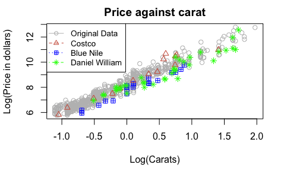

```r
legend("topleft", c("Original Data","Costco","Blue Nile","Daniel William"), lty=c(1,2,3,4),
       pch=c(1,2,12,8),
       cex = 0.85,
       col=c("grey","coral3","blue","green"))
```

Create model (without any interactions)

```r
#model with all additive terms and condensed #classes
test_lm = lm(price~carat+cut+clarity+color, data=diamonds)
summary(test_lm)
```

```
Call:
lm(formula = price ~ carat + cut + clarity + color, data = diamonds)

Residuals:
     Min       1Q   Median       3Q      Max
-0.78426 -0.11452 -0.00095  0.12406  0.63508

Coefficients:
                     Estimate Std. Error t value Pr(>|t|)
(Intercept)          7.804452   0.015462 504.748  < 2e-16 ***
carat                2.232326   0.009374 238.152  < 2e-16 ***
cutcutgroup1         0.291887   0.042319   6.897 8.54e-12 ***
cutcutgroup2         0.165785   0.011195  14.808  < 2e-16 ***
clarityclaritygroup1 0.459705   0.027332  16.819  < 2e-16 ***
clarityclaritygroup2 0.232417   0.011392  20.401  < 2e-16 ***
colorcolorgroup1     0.373542   0.017305  21.586  < 2e-16 ***
colorcolorgroup2     0.222538   0.013392  16.618  < 2e-16 ***
---
Signif. codes:  0 ‘***’ 0.001 ‘**’ 0.01 ‘*’ 0.05 ‘.’ 0.1 ‘ ’ 1

Residual standard error: 0.1851 on 1206 degrees of freedom
Multiple R-squared:  0.9797,    Adjusted R-squared:  0.9796
F-statistic:  8334 on 7 and 1206 DF,  p-value: < 2.2e-16
```

Initial look to see if predictions based on original dataset are compatible with externally sourced diamonds.

```r
pExtras <- data.frame(predict(test_lm, newdata = subExtras, interval = "prediction"))
subExtras$predicted <- exp(pExtras$fit)

subExtras
```

|  | carat | clarity | color | cut | price | vendor | o_price | o_carat | subcolor | subpch | predicted |
| --- | --- | --- | --- | --- | --- | --- | --- | --- | --- | --- | --- |
| 16 | 0.10436002 | claritygroup3 | colorgroup2 | cutgroup3 | 8.294300 | BlueNile | 4001 | 1.010 | blue | 12 | 3865.9227 |
| 17 | 0.33647224 | claritygroup3 | colorgroup3 | cutgroup3 | 8.304495 | BlueNile | 4042 | 1.300 | blue | 12 | 5195.6030 |
| 18 | 0.00000000 | claritygroup3 | colorgroup2 | cutgroup3 | 8.124447 | BlueNile | 3376 | 0.900 | blue | 12 | 3062.5098 |
| 19 | -0.69314718 | claritygroup3 | colorgroup3 | cutgroup3 | 5.945421 | BlueNile | 382 | 0.400 | blue | 12 | 521.7149 |
| 20 | -0.69314718 | claritygroup2 | colorgroup3 | cutgroup3 | 6.180017 | BlueNile | 483 | 0.400 | blue | 12 | 658.2194 |
| 21 | -0.43078292 | claritygroup2 | colorgroup3 | cutgroup2 | 6.575076 | BlueNile | 717 | 0.550 | blue | 12 | 1395.4965 |
| 22 | -0.32850407 | claritygroup3 | colorgroup3 | cutgroup2 | 6.906755 | BlueNile | 999 | 0.620 | blue | 12 | 1389.7905 |
| 23 | -0.21072103 | claritygroup3 | colorgroup3 | cutgroup3 | 6.921658 | BlueNile | 1014 | 0.710 | blue | 12 | 1531.5782 |
| 24 | 0.00000000 | claritygroup3 | colorgroup3 | cutgroup3 | 7.478170 | BlueNile | 1769 | 0.900 | blue | 12 | 2451.4920 |
| 25 | 0.00000000 | claritygroup2 | colorgroup3 | cutgroup3 | 7.816014 | BlueNile | 2480 | 0.900 | blue | 12 | 3092.9143 |

[output cut: 60 more lines]

```r
NA
```

Graph of prediction intervals compared to external data points

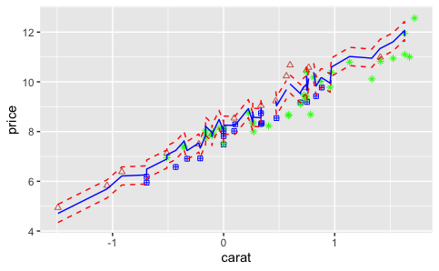

```r
pred.int <- predict(test_lm, newdata = subExtras, interval = "prediction")

ggdata <- cbind(subExtras,pred.int)
library("ggplot2")

p <- ggplot(ggdata, aes(carat, price)) +
  geom_point(pch=subExtras$subpch,
             col=subExtras$subcolor)
p + geom_line(aes(y = lwr), color = "red", linetype = "dashed")+
  geom_line(aes(y = upr), color = "red", linetype = "dashed") +
  geom_line(aes(y = fit), color = "blue")
```

```r
#  stat_smooth(method = "loess")  # "gam" and "lm" are other options

#NB I can't figure out how to make a legend :-(
```

Bar chart showing what percentages of external-sample data are under/over the prediction interval of our model.

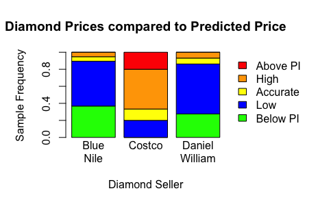

```r
subExtras$upr <- exp(pExtras$upr)
subExtras$lwr <- exp(pExtras$lwr)

# Define 5 categories for prediction accuracy:
# --Below and above PI
# --Top- and bottom- half within PI
# --Within 5% of model-predicted mean price
subExtras$PAccuracy[subExtras$o_price < subExtras$lwr] = "Below PI"
subExtras$PAccuracy[subExtras$o_price >= subExtras$lwr] = "Low"
subExtras$PAccuracy[subExtras$o_price > (subExtras$predicted * 0.95)] = "Accurate"
subExtras$PAccuracy[subExtras$o_price >= (subExtras$predicted * 1.05)] = "High"
subExtras$PAccuracy[subExtras$o_price >= subExtras$upr] = "Above PI"

M <- c("Below PI", "Low", "Accurate", "High", "Above PI")
subExtras$PAccuracy <- factor(subExtras$PAccuracy, levels = M)
counts <- table(subExtras$PAccuracy, subExtras$vendor)
counts2 <- prop.table(counts, 2) # change counts to %
par(mfrow=c(1, 1), mar=c(5, 5, 4, 8))
barplot(counts2, main="Diamond Prices compared to Predicted Price",
  xlab="Diamond Seller",
  ylab="Sample Frequency",
  col=c("green","blue","yellow","orange","red"),
  names.arg=c("Blue\nNile","Costco\n","Daniel\nWilliam"),
  legend = rownames(counts),
  args.legend = list(x = "topright", bty = "n", inset=c(-0.5, 0)))
```